# BCB420 Assignment 1

Mikael Gouwtama

2024-02-19

# Introduction

This dataset was collected to explore the impact of heterozygous (cMyBP-C+/-) and homozygous (cMyBP-C-/-) truncation mutations in the cardiac myosin binding protein C (cMyBP-C) gene on hypertrophic cardiomyopathy (HCM) using human induced pluripotent stem cells (hiPSCs). Utilizing CRISPR-Cas9 technology, researchers generated iPSC-derived cardiomyocytes and engineered cardiac tissue constructs (ECTs) to study contractile function, calcium handling, and calcium sensitivity. The investigation revealed that cMyBP-C mutations lead to progressive calcium-handling abnormalities and contractile dysfunction, providing insights into the molecular mechanisms underlying HCM (De Lange et al. 2023).

The figure below is obtained from Figure 5 of the author’s publication. It illustrates the relationship between calcium dynamics and muscle contraction in heart cells with different cMyBP-C alleles. The broken traces represent cMyBP-C+/+ hiPSC-ECTs, grey traces represent cMyBP-C+/- hiPSC-ECTs, and black traces correspond to cMyBP-C-/- hiPSC-ECTs. The result indicates that mutations in cMyBP-C lead to faster calcium transitions and decreased force generation, with the most significant changes occuring in the homozygous mutant (cMyBP-C-/-) hiPS-ECTs, suggesting a heightened sensitivity to calcium in these cells (De Lange et al. 2023).

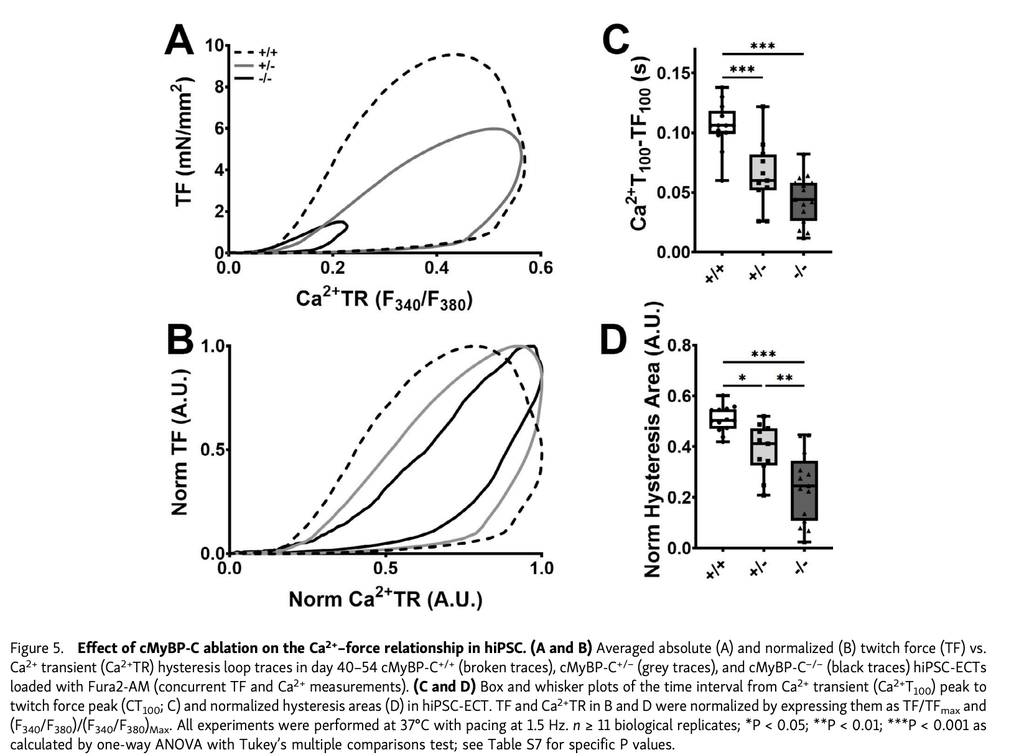

**Why is this dataset of interest to you?** I am currently working on a research project exploring the effect of circMYBPC3 expression on cardiac fibroblast proliferation. We found an increase proliferation rate in overexpressed circMYBPC3 cells. This leads to the clinical presentation of HCM, where HCM patients also reported an increase in circMYBPC3 RNA levels. Thus, I am interested in the other effects that the gene encoding for circMYBPC3 plays in the progression of HCM. This study and dataset perfectly covers for that, as they look at the cMyBP knockouts and its effect towards processes involved in cardiac physiology and HCM.

**What are the control and test conditions of the dataset?** The control is the homozygous wild-type cMyBP hiPSC-ECTs (cMyBP-C+/+) The test conditions are the heterozygous (cMyBP-C+/-) and homozygous (cMyBP-C-/-) truncation mutated hiPSC-ECTs.

# Preparing Data and Initial Cleaning

We can start by importing the following packages from r: GEOquery (Davis and Meltzer 2007), knitr (Xie 2017), dplyr (Wickham et al. 2014), and edgeR (Robinson, McCarthy, and Smyth 2010).

The data was obtained from the GEO accession number: GSE224129. The supplementary file associated with that GEO number contains the gene expression raw counts which we will use throughout the subsequent analysis.

```r
#Getting the GEO accession data
data_set_geoid <- "GSE224129"
gse <- getGEO(data_set_geoid, GSEMatrix=FALSE)

#getting the names of the supplementary files
sfilenames = getGEOSuppFiles(data_set_geoid, fetch_files = FALSE)
data_filename <- sfilenames$fname[1]
```

Download the expression data if it has not been downloaded yet

```r
#location to download and store files
download_dir <- file.path(getwd())

#check to see if the file exists already before you download them
#only download files that we don't have from the set of supplementary files
missing_files <- sfilenames$fname[!unlist(lapply(sfilenames$fname, FUN=function(x) {
  file.exists((
    file.path(download_dir, data_set_geoid, x)))}))]

if(length(missing_files) > 0){
  for(i in 1:length(missing_files)){
    #get the supplementary files
    sfiles = getGEOSuppFiles(data_set_geoid, filter_regex = missing_files[i], baseDir = download_dir, fetch_files = TRUE)
  }
}
```

We can see how many genes and total samples are present initially in the files as follows

```r
homo_hetero_wt_data <- read.table (
  file.path(download_dir, data_set_geoid, data_filename), header = TRUE, check.names = TRUE)

dim(homo_hetero_wt_data)
```

```
## [1] 58243    12
```

Here’s what the original data looks like

```r
head(homo_hetero_wt_data, format = "html")
```

```
##                 X2.0020801E7 X2.0020802E7 X2.0020805E7 X2.0020806E7
## ENSG00000000003       646.00       642.00       748.00       704.00
## ENSG00000000005         8.00        14.00        23.00        32.00
## ENSG00000000419       793.00       665.00       842.00       841.00
## ENSG00000000457       285.86       285.36       429.14       431.53
## ENSG00000000460        96.14        65.64        90.86        90.47
## ENSG00000000938         0.00         0.00         0.00         0.00
##                 X2.0020807E7 X2.0020809E7 X2.0020811E7 X2.0020813E7
## ENSG00000000003       762.00       768.00       680.00       666.00
## ENSG00000000005        27.00        13.00        23.00         8.00
## ENSG00000000419       709.00       945.00       664.00       739.00
## ENSG00000000457       381.85       385.21       384.75       306.05
## ENSG00000000460        66.15        69.79        61.25        74.95
## ENSG00000000938         0.00         0.00         0.00         0.00
##                 X2.0020814E7 X2.0020815E7 X2.0020816E7 X2.002081E7
## ENSG00000000003       774.00       554.00       596.00       623.0
## ENSG00000000005        13.00         4.00        12.00        15.0
## ENSG00000000419       881.00       680.00       625.00       550.0
## ENSG00000000457       368.03       372.94       284.03       369.5
## ENSG00000000460       106.97        69.06        87.97        74.5
## ENSG00000000938         1.00         0.00         0.00         0.0
```

In the GEO website, it mentions that the column names indicate the different samples and their genotype. We can then reorder and rename the column so that the different conditions are easily comparable

```
##                 homo mutant 1 homo mutant 2 homo mutant 3 homo mutant 4
## ENSG00000000003        646.00        642.00        748.00        704.00
## ENSG00000000005          8.00         14.00         23.00         32.00
## ENSG00000000419        793.00        665.00        842.00        841.00
## ENSG00000000457        285.86        285.36        429.14        431.53
## ENSG00000000460         96.14         65.64         90.86         90.47
## ENSG00000000938          0.00          0.00          0.00          0.00
##                 hetero mutant 1 hetero mutant 2 hetero mutant 3 hetero mutant 4
## ENSG00000000003          762.00          768.00          680.00           623.0
## ENSG00000000005           27.00           13.00           23.00            15.0
## ENSG00000000419          709.00          945.00          664.00           550.0
## ENSG00000000457          381.85          385.21          384.75           369.5
## ENSG00000000460           66.15           69.79           61.25            74.5
## ENSG00000000938            0.00            0.00            0.00             0.0
##                 wild type 1 wild type 2 wild type 3 wild type 4
## ENSG00000000003      666.00      774.00      554.00      596.00
## ENSG00000000005        8.00       13.00        4.00       12.00
## ENSG00000000419      739.00      881.00      680.00      625.00
## ENSG00000000457      306.05      368.03      372.94      284.03
## ENSG00000000460       74.95      106.97       69.06       87.97
## ENSG00000000938        0.00        1.00        0.00        0.00
```

# Assessing Data

## Statistical Overview

Before we modify the data, we can first look at the statistical overview of the data. Here, we’ll be performing an analysis of the minimal value, median, maximal value, first quartile, and third quartile for all the samples.

```r
# Assign column names to each group for easy reference
colnames(homo_hetero_wt_data) <- c("homo_mutant_1", "homo_mutant_2", "homo_mutant_3", "homo_mutant_4",
                                   "hetero_mutant_1", "hetero_mutant_2", "hetero_mutant_3", "hetero_mutant_4",
                                   "wild_type_1", "wild_type_2", "wild_type_3", "wild_type_4")

# Subset data into three conditions
homo_data <- homo_hetero_wt_data[, 1:4]
hetero_data <- homo_hetero_wt_data[, 5:8]
wt_data <- homo_hetero_wt_data[, 9:12]

# Define the function to calculate the statistics
calc_stats <- function(data) {
  data.frame(
    min = apply(data, 2, min, na.rm = TRUE),
    Q1 = apply(data, 2, quantile, probs = 0.25, na.rm = TRUE),
    median = apply(data, 2, median, na.rm = TRUE),
    mean = apply(data, 2, mean, na.rm = TRUE),
    Q3 = apply(data, 2, quantile, probs = 0.75, na.rm = TRUE),
    max = apply(data, 2, max, na.rm = TRUE)
  )
}

# Subset data into three conditions
homo_data <- homo_hetero_wt_data[, 1:4]
hetero_data <- homo_hetero_wt_data[, 5:8]
wt_data <- homo_hetero_wt_data[, 9:12]

# Calculate statistics for each condition
homo_stats <- calc_stats(homo_data)
hetero_stats <- calc_stats(hetero_data)
wt_stats <- calc_stats(wt_data)

# Combine the statistics into a single data frame for presentation
overview_stats <- rbind(homo_stats, hetero_stats, wt_stats)

# Print the overview statistics
print(overview_stats)
```

```
##                 min Q1 median     mean     Q3     max
## homo_mutant_1     0  0      0 527.2288 15.000 6350547
## homo_mutant_2     0  0      0 432.1083 11.870 5915485
## homo_mutant_3     0  0      0 522.3324 16.000 6493394
## homo_mutant_4     0  0      0 504.0599 13.000 6616973
## hetero_mutant_1   0  0      0 479.6345 15.000 6138994
## hetero_mutant_2   0  0      0 515.4469 15.000 5801683
## hetero_mutant_3   0  0      0 495.7880 15.000 6004665
## hetero_mutant_4   0  0      0 414.2962 13.000 5719939
## wild_type_1       0  0      0 467.4136 14.650 5100450
## wild_type_2       0  0      0 509.1416 15.000 5757372
## wild_type_3       0  0      0 444.1534 14.000 5923546
## wild_type_4       0  0      0 459.6480 15.265 5368057
```

Looking at the statistics above, it seems that the median and the first quartile (Q1) values for all samples are zero, which could indicate a large number of zero values or possibly a skewed distribution with many low values in their dataset. Furthermore, the mean values are relatively high compared to the medians, suggesting a right-skewed distribution. As such, the data should be cleaned to have a better visualization. This includes removing the zeros as we’ll perform soon.

## Biological Overview

We can also perform another assessment on the samples from a more biological perspective. Specifically, we can look at the tissue types, cell lines, cell types, genotype, treatments, and the sex of the originating individual for all the samples.

```r
list_of_samples <- gse@gsms

samples_type <- do.call(rbind,
                       lapply(list_of_samples,
                              FUN=function(x) {
                                c(x@header$title,
                                  x@header$characteristics_ch1)
                                  }
                              )
                       )

colnames(samples_type) <- c("title", "tissue", "cell line", "cell type", "genotype", "treatment", "sex")

samples_type[, 'tissue'] <- gsub(samples_type[, 'tissue'], pattern = "tissue: ", replacement = "")
samples_type[, 'cell line'] <- gsub(samples_type[, 'cell line'], pattern = "cell line: ", replacement = "")
samples_type[, 'cell type'] <- gsub(samples_type[, 'cell type'], pattern = "cell type: ", replacement = "")
samples_type[, 'genotype'] <- gsub(samples_type[, 'genotype'], pattern = "genotype: ", replacement = "")
samples_type[, 'treatment'] <- gsub(samples_type[, 'treatment'], pattern = "treatment: ", replacement = "")
samples_type[, 'sex'] <- gsub(samples_type[, 'sex'], pattern = "sex: ", replacement = "")

kable(samples_type[1:12, ], format = "html")
```

|  | title | tissue | cell line | cell type | genotype | treatment | sex |
| --- | --- | --- | --- | --- | --- | --- | --- |
| GSM7015601 | cMyBP-C+/+ ECT 1 [s20020813E7] | Engineered Cardiac | DF19-9-11T.H | iPSC-drived cardiomyocyte and cardiac fibroblast | cMyBP-C+/+ | None | Sex: Male |
| GSM7015602 | cMyBP-C+/+ ECT 2 [s20020814E7] | Engineered Cardiac | DF19-9-11T.H | iPSC-drived cardiomyocyte and cardiac fibroblast | cMyBP-C+/+ | None | Sex: Male |
| GSM7015603 | cMyBP-C+/+ ECT 3 [s20020815E7] | Engineered Cardiac | DF19-9-11T.H | iPSC-drived cardiomyocyte and cardiac fibroblast | cMyBP-C+/+ | None | Sex: Male |
| GSM7015604 | cMyBP-C+/+ ECT 4 [s20020816E7] | Engineered Cardiac | DF19-9-11T.H | iPSC-drived cardiomyocyte and cardiac fibroblast | cMyBP-C+/+ | None | Sex: Male |
| GSM7015605 | cMyBP-C+/- ECT 1 [s20020807E7] | Engineered Cardiac | DF19-9-11T.H | iPSC-drived cardiomyocyte and cardiac fibroblast | cMyBP-C+/- | None | Sex: Male |
| GSM7015606 | cMyBP-C+/- ECT 2 [s20020809E7] | Engineered Cardiac | DF19-9-11T.H | iPSC-drived cardiomyocyte and cardiac fibroblast | cMyBP-C+/- | None | Sex: Male |
| GSM7015607 | cMyBP-C+/- ECT 3 [s20020811E7] | Engineered Cardiac | DF19-9-11T.H | iPSC-drived cardiomyocyte and cardiac fibroblast | cMyBP-C+/- | None | Sex: Male |
| GSM7015608 | cMyBP-C+/- ECT 4 [s2002081E7] | Engineered Cardiac | DF19-9-11T.H | iPSC-drived cardiomyocyte and cardiac fibroblast | cMyBP-C+/- | None | Sex: Male |
| GSM7015609 | cMyBP-C-/- ECT 1 [s20020801E7] | Engineered Cardiac | DF19-9-11T.H | iPSC-drived cardiomyocyte and cardiac fibroblast | cMyBP-C-/- | None | Sex: Male |
| GSM7015610 | cMyBP-C-/- ECT 2 [s20020802E7] | Engineered Cardiac | DF19-9-11T.H | iPSC-drived cardiomyocyte and cardiac fibroblast | cMyBP-C-/- | None | Sex: Male |
| GSM7015611 | cMyBP-C-/- ECT 3 [s20020805E7] | Engineered Cardiac | DF19-9-11T.H | iPSC-drived cardiomyocyte and cardiac fibroblast | cMyBP-C-/- | None | Sex: Male |
| GSM7015612 | cMyBP-C-/- ECT 4 [s20020806E7] | Engineered Cardiac | DF19-9-11T.H | iPSC-drived cardiomyocyte and cardiac fibroblast | cMyBP-C-/- | None | Sex: Male |

Looking at the data assessment above, it appeared that all the cells are engineered cardiac cells, which are iPSC-drived cardiomyocyte and cardiac fibroblast. This makes sense as those two cell types are the most common cell types present in the heart. They are derived from the DF19-0-11T.H cell lines, which are foreskin fibroblast, which are stem cells that can be induced to other cell types, including cardiomyocyte and cardiac fibroblast as used here (Yu et al. 2009).

The different sample conditions can be nicely categorized into the following table, including the count as the number of samples in each condition.

```
##    sample_type_dt count
## 1:     cMyBP-C+/+     4
## 2:     cMyBP-C+/-     4
## 3:     cMyBP-C-/-     4
```

# Cleaning the Data

Before we continue with our analysis and preparation of the data, we would want to clean the data. One of the main component in cleaning the data involves removing those genes that has 0 counts. Earlier, we saw that our data does include quite a few of genes that has 0 counts on them. Hence, the 0 Q1 and median values for all the samples.

The following chunk of code will eliminate those low counts:

```r
#minimal number of samples
min_num_samples <- 4

data_matrix <- as.matrix(homo_hetero_wt_data)

#get rid of low counts
keep = rowSums(cpm(data_matrix) >1) > min_num_samples
filtered_data_matrix = data_matrix[keep,]
head(filtered_data_matrix)
```

```
##                 homo_mutant_1 homo_mutant_2 homo_mutant_3 homo_mutant_4
## ENSG00000000003        646.00        642.00        748.00        704.00
## ENSG00000000419        793.00        665.00        842.00        841.00
## ENSG00000000457        285.86        285.36        429.14        431.53
## ENSG00000000460         96.14         65.64         90.86         90.47
## ENSG00000000971       1183.00        927.00       1036.00       1120.00
## ENSG00000001036       1433.57       1295.65       1585.30       1550.88
##                 hetero_mutant_1 hetero_mutant_2 hetero_mutant_3 hetero_mutant_4
## ENSG00000000003          762.00          768.00          680.00          623.00
## ENSG00000000419          709.00          945.00          664.00          550.00
## ENSG00000000457          381.85          385.21          384.75          369.50
## ENSG00000000460           66.15           69.79           61.25           74.50
## ENSG00000000971         1007.00         1381.96          982.88         1083.00
## ENSG00000001036         1569.73         1859.65         1422.74         1294.56
##                 wild_type_1 wild_type_2 wild_type_3 wild_type_4
## ENSG00000000003      666.00      774.00      554.00      596.00
## ENSG00000000419      739.00      881.00      680.00      625.00
## ENSG00000000457      306.05      368.03      372.94      284.03
## ENSG00000000460       74.95      106.97       69.06       87.97
## ENSG00000000971     1297.00     1634.00     1135.85     1123.99
## ENSG00000001036     1558.58     1775.40     1281.56     1408.68
```

Another key step in this section is to remove any outliers or any samples that the author did not use. However, the author’s publication did not mention any existence of an outlier, extreme values or anomalies. They also used all twelve of their samples. Thus, we did not further remove any of the data.

# Mapping the Data

In the raw counts data provided by the authors, they use the Ensembl gene IDs to identify the genes. However, we would like to map these IDs to the HUGO symbols, specifically to the HGNC symbols.

```r
ids2convert <- rownames(filtered_data_matrix)

#check to see if id_conversion file exists (computationally intensive)
conversion_stash <- "id_conversion.rds"
if(file.exists(conversion_stash)){
  id_conversion <- readRDS(conversion_stash)
}  else {
   id_conversion <- getBM(attributes =
c("ensembl_gene_id","hgnc_symbol"),
                            filters = c("ensembl_gene_id"),
                            values = ids2convert,
                            mart = ensembl)
   saveRDS(id_conversion, conversion_stash)
}
```

Here are the number of genes that we were able to map:

```r
length(which(rownames(filtered_data_matrix) %in%
               id_conversion$ensembl_gene_id))
```

```
## [1] 13170
```

Out of our total ensembl genes that we started with:

```r
nrow(filtered_data_matrix)
```

```
## [1] 13249
```

And here is the difference between them. In other words, this is the number of genes without a valid Ensembl gene ID.

```r
nrow(filtered_data_matrix) - length(which(rownames(filtered_data_matrix)
                                  %in%
                                    id_conversion$ensembl_gene_id))
```

```
## [1] 79
```

This low value indicates that a good amount of our genes were able to be mapped to the HGNC symbols. We can ignore the unmapped genes.

Before we merge the HGNC symbols to our data, we also want to check for the number of genes with a valid Ensembl gene ID but has no HGNC symbol. These genes are those with N/A listed as the HGNC symbols.

```r
sum(id_conversion$hgnc_symbol == "")
```

```
## [1] 464
```

Next, we want to isolate only those genes with a valid HGNC symbol to be used when merging with our dataset.

```r
id_conversion <- id_conversion[id_conversion$hgnc_symbol != "", ]
```

We can also look to see if there are any genes that are duplicated in the dataset. Here, we found one gene to be duplicated “GUSBP11”

```r
# Find duplicate HGNC symbols
hgnc_symbol_duplicate <- id_conversion$hgnc_symbol[duplicated(id_conversion$hgnc_symbol)]
print(hgnc_symbol_duplicate)
```

```
## [1] "GUSBP11"
```

Finally, we can merge the hgnc symbols with the dataset using the following code:

```r
# Remove rows with NA hgnc_symbol
filtered_data_without_NA <- id_conversion[!is.na(id_conversion$hgnc_symbol), ]

# Merge filtered_data_without_NA with filtered_data_matrix
merged_data <- merge(filtered_data_without_NA, filtered_data_matrix, by.x = "ensembl_gene_id", by.y = "row.names", all.x = TRUE)

# Identify and remove duplicate rows based on hgnc_symbol, keeping the first occurrence (removing the "GUSPB11" duplicate)
merged_data <- merged_data[!duplicated(merged_data$hgnc_symbol), ]
```

The final amount of valid and non-duplicated genes with a valid hgnc symbol are as follows:

```r
nrow(merged_data)
```

```
## [1] 12705
```

Therefore, among the 13249 total Ensembl genes we started with, after removing 79 genes that we’re unable to map, another 464 genes with N/A listed as their hgnc symbol, and 1 duplicate, we are left with the 12705 genes that we’ll use for normalization in the following section.

However, before doing the normalization, we can set the HGNC symbols as row names.

```r
# Set the HGNC symbols as rownames
rownames(merged_data) <- merged_data$hgnc_symbol

# Remove the HGNC symbol column as it is now the rowname
merged_data <- merged_data[, !colnames(merged_data) %in% c("hgnc_symbol", "ensembl_gene_id")]

# See the merged data
head(merged_data)
```

```
##        homo_mutant_1 homo_mutant_2 homo_mutant_3 homo_mutant_4 hetero_mutant_1
## TSPAN6        646.00        642.00        748.00        704.00          762.00
## DPM1          793.00        665.00        842.00        841.00          709.00
## SCYL3         285.86        285.36        429.14        431.53          381.85
## FIRRM          96.14         65.64         90.86         90.47           66.15
## CFH          1183.00        927.00       1036.00       1120.00         1007.00
## FUCA2        1433.57       1295.65       1585.30       1550.88         1569.73
##        hetero_mutant_2 hetero_mutant_3 hetero_mutant_4 wild_type_1 wild_type_2
## TSPAN6          768.00          680.00          623.00      666.00      774.00
## DPM1            945.00          664.00          550.00      739.00      881.00
## SCYL3           385.21          384.75          369.50      306.05      368.03
## FIRRM            69.79           61.25           74.50       74.95      106.97
## CFH            1381.96          982.88         1083.00     1297.00     1634.00
## FUCA2          1859.65         1422.74         1294.56     1558.58     1775.40
##        wild_type_3 wild_type_4
## TSPAN6      554.00      596.00
## DPM1        680.00      625.00
## SCYL3       372.94      284.03
## FIRRM        69.06       87.97
## CFH        1135.85     1123.99
## FUCA2      1281.56     1408.68
```

# Normalization

We’ll perform both pre and post-normalization analysis to visualize the effect of normalization to our dataset.

## Pre-normalization

Before normalizing the data, we can visualize the distribution of the data using a boxplot and also look at its density distribution. Here’s the figure for the raw, unnormalized counts.

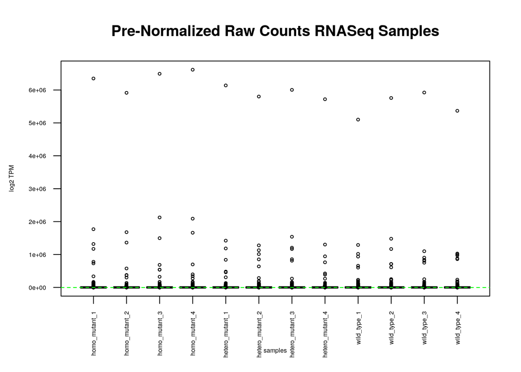

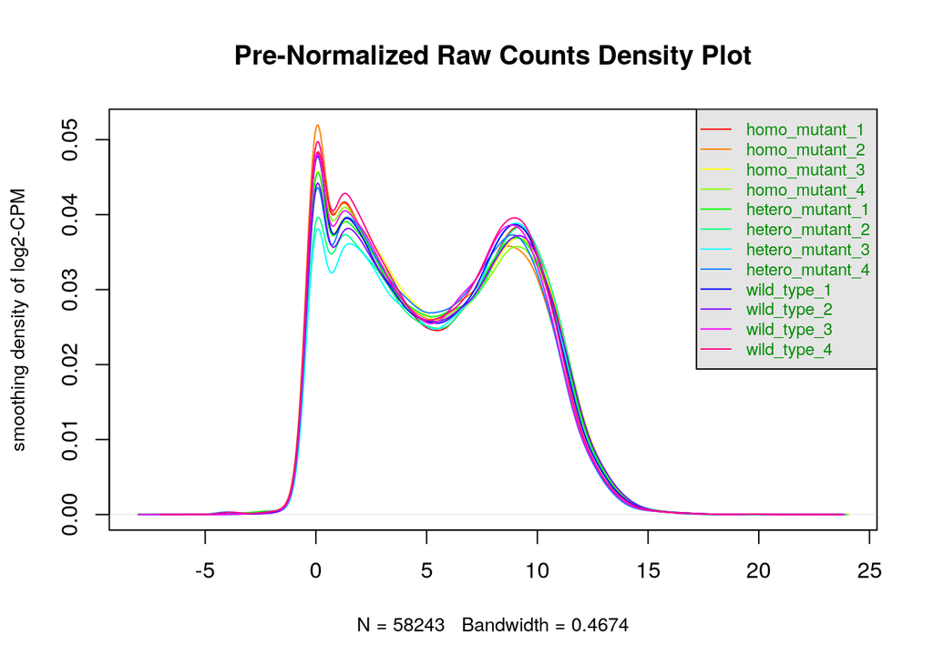

Immediately, you can see that this pre-normalization figures is not really nice. The boxplot shows a lot of data around the 0 in the raw counts that we obtained from the supplementary files given in GEO. The density plot also shows quite a large bandwidth that appeared bimodal in shape.

## Post-normalization

Now, we can see how the data clean-up and normalization will effect our plots. The normalization method we’ll use is Trimmed Mean of M-values (TMM). This method is used based on the hypothesis that most genes are not differentially expressed.

```r
# Convert the data frame to a matrix
merged_matrix <- as.matrix(merged_data)

# Create an edgeR container for RNAseq count data
d = DGEList(counts=merged_matrix, group=sample_type_dt$genotype)

# Calculate the normalization factors
d = calcNormFactors(d)

normalized_counts <- cpm(d)
```

Next, we’ll visualize the distribution of our normalized data and its density as we did previously with the pre-normalized data.

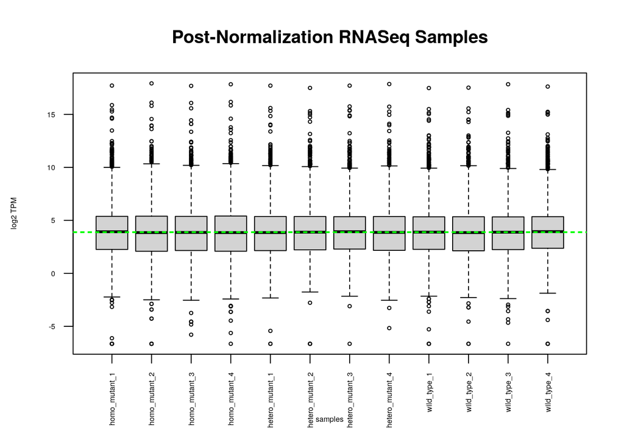

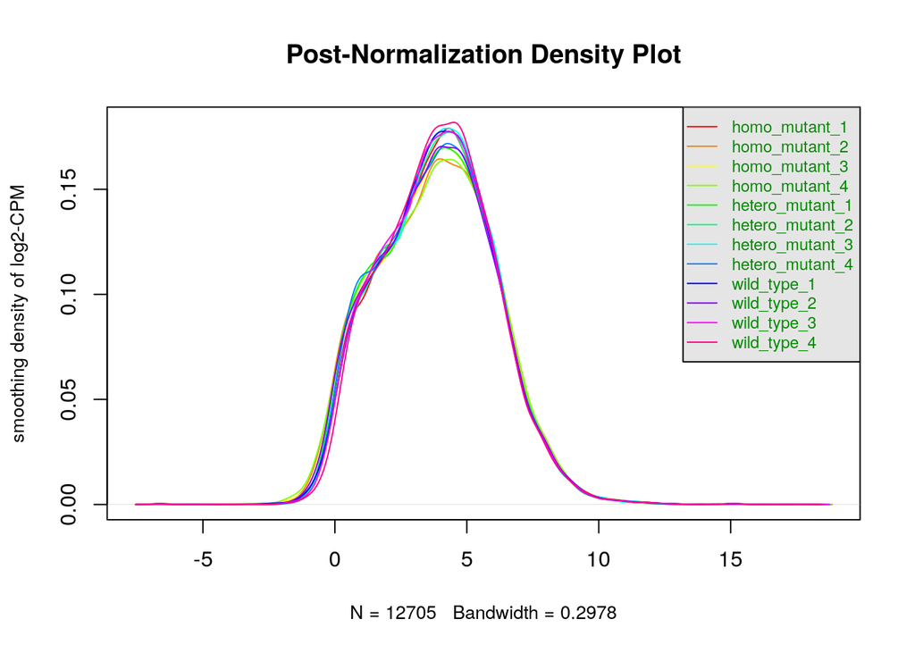

# MDS plot

To look at the level of similarity and clustering of the samples, we can use a multidimensional scaling (MDS) plot.

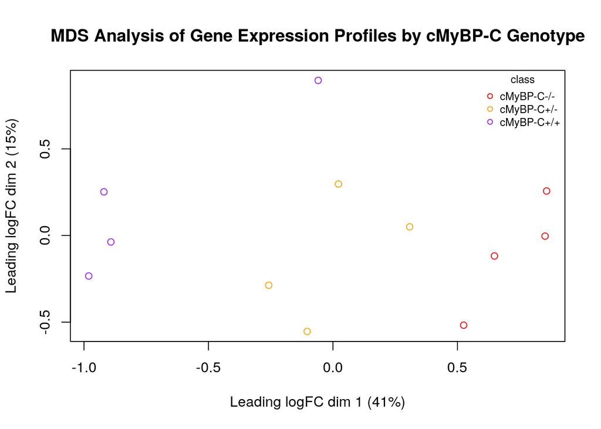

```r
limma::plotMDS(d, labels=NULL,pch=1, main = "MDS Analysis of Gene Expression Profiles by cMyBP-C Genotype",
  col = c("red", "orange", "purple") [factor(sample_type_dt$genotype)])

legend("topright",
       legend=levels(factor(sample_type_dt$genotype)),
       pch=c(1), col=
c("red", "orange", "purple"),title="class",
       bty = 'n', cex=0.75)
```

# Final Coverage

We can compare the number of final included genes with the initial number of genes in the original data.

Here is the number of genes and counts in our normalized data

```r
a <- nrow(normalized_counts)
a
```

```
## [1] 12705
```

Here is the number of genes and counts in our originial data

```r
b <- nrow(homo_hetero_wt_data)
b
```

```
## [1] 58243
```

Thus, the coverage can be calculated as follows

```r
a/b*100
```

```
## [1] 21.81378
```

The final coverage of our dataset is 21.8%.

# Normalized and HUGO Mapped Dataset

Below is an overview of the finalized, prepared, normalized and hgnc symbol mapped dataset.

```r
head(normalized_counts)
```

```
##        homo_mutant_1 homo_mutant_2 homo_mutant_3 homo_mutant_4 hetero_mutant_1
## TSPAN6     21.918656     26.960227      24.32877      24.93080       26.586992
## DPM1       26.906338     27.926092      27.38613      29.78239       24.737766
## SCYL3       9.699175     11.983443      13.95782      15.28180       13.323154
## FIRRM       3.262012      2.756494       2.95523       3.20382        2.308044
## CFH        40.138964     38.928552      33.69600      39.66263       35.135303
## FUCA2      48.640756     54.409686      51.56203      54.92142       54.769553
##        hetero_mutant_2 hetero_mutant_3 hetero_mutant_4 wild_type_1 wild_type_2
## TSPAN6       24.438123       24.284536       25.948292    23.91504   25.278490
## DPM1         30.070347       23.713135       22.907802    26.53636   28.773061
## SCYL3        12.257564       13.740405       15.389878    10.98979   12.019693
## FIRRM         2.220751        2.187394        3.102966     2.69134    3.493592
## CFH          43.974621       35.101154       45.107545    46.57329   53.365700
## FUCA2        59.174942       50.809678       53.919135    55.96623   57.983760
##        wild_type_3 wild_type_4
## TSPAN6   21.964398    22.41385
## DPM1     26.959911    23.50446
## SCYL3    14.785925    10.68155
## FIRRM     2.738017     3.30830
## CFH      45.032963    42.27004
## FUCA2    50.809917    52.97642
```

# Interpretation and Documentation

**Why is the dataset of interest to you?** Introduction

**What are the control and test conditions of the dataset?** Introduction

**How many samples in each of the conditions of your dataset?** There are 12 samples in total, 4 for each genotype (cMyBP-C+/+, cMyBP-C+/-, and cMyBP-C-/-). Biological Overview

**Were there expression values that were not unique for specific genes? How did you handle these?** Yes, there are 79 genes in our dataset without a valid Ensembl gene ID. Since they only account for a small portion of our dataset, we removed those genes.Mapping the Data

**Were there expression values that could not be mapped to current HUGO symbols?** Yes, we found 464 had N/A listed as the HGNC symbols. Hence, they could not be mapped to the current HUGO symbols. We also removed those genes as they only account for a small portion of our dataset. Mapping the Data

**How did you handle replicates?** We found a replicate where two genes using the Ensembl gene ID that maps to the same HGNC symbol, “GUSBP11”. We remove one of the replicates, specifically the second one, which has a very low expression value (low counts). Mapping the Data

**What is the final coverage of your dataset?** The final coverage of our dataset is 21.8%. Final Coverage

# References

Davis, Sean, and Paul S Meltzer. 2007. “GEOquery: A Bridge Between the Gene Expression Omnibus (GEO) and BioConductor.” *Bioinformatics* 23 (14): 1846–47.

De Lange, Willem J, Emily T Farrell, Jonathan J Hernandez, Alana Stempien, Caroline R Kreitzer, Derek R Jacobs, Dominique L Petty, Richard L Moss, Wendy C Crone, and J Carter Ralphe. 2023. “cMyBP-c Ablation in Human Engineered Cardiac Tissue Causes Progressive Ca2+-Handling Abnormalities.” *Journal of General Physiology* 155 (4): e202213204.

Robinson, Mark D, Davis J McCarthy, and Gordon K Smyth. 2010. “edgeR: A Bioconductor Package for Differential Expression Analysis of Digital Gene Expression Data.” *Bioinformatics* 26 (1): 139–40.

Wickham, Hadley, R Francois, L Henry, and K Müller. 2014. “Dplyr.” In *useR! Conference*.

Xie, Yihui. 2017. *Dynamic Documents with r and Knitr*. CRC Press.

Yu, Junying, Kejin Hu, Kim Smuga-Otto, Shulan Tian, Ron Stewart, Igor I Slukvin, and James A Thomson. 2009. “Human Induced Pluripotent Stem Cells Free of Vector and Transgene Sequences.” *Science* 324 (5928): 797–801.